# DS311 - R Lab Assignment

Gabrielle Salamanca

2023-04-03

## R Assignment 1

- In this assignment, we are going to apply some of the build in data set in R for descriptive statistics analysis.
- To earn full grade in this assignment, students need to complete the coding tasks for each question to get the result.
- After finished all the questions, knit the document into HTML format for submission.

### Question 1

Using the **mtcars** data set in R, please answer the following questions.

```r
# Loading the data
data(mtcars)

# Head of the data set
head(mtcars)
```

|  | mpg | cyl | disp | hp | drat | wt | qsec | vs | am | gear | carb |
| --- | --- | --- | --- | --- | --- | --- | --- | --- | --- | --- | --- |
| Mazda RX4 | 21.0 | 6 | 160 | 110 | 3.90 | 2.620 | 16.46 | 0 | 1 | 4 | 4 |
| Mazda RX4 Wag | 21.0 | 6 | 160 | 110 | 3.90 | 2.875 | 17.02 | 0 | 1 | 4 | 4 |
| Datsun 710 | 22.8 | 4 | 108 | 93 | 3.85 | 2.320 | 18.61 | 1 | 1 | 4 | 1 |
| Hornet 4 Drive | 21.4 | 6 | 258 | 110 | 3.08 | 3.215 | 19.44 | 1 | 0 | 3 | 1 |
| Hornet Sportabout | 18.7 | 8 | 360 | 175 | 3.15 | 3.440 | 17.02 | 0 | 0 | 3 | 2 |
| Valiant | 18.1 | 6 | 225 | 105 | 2.76 | 3.460 | 20.22 | 1 | 0 | 3 | 1 |

1. Report the number of variables and observations in the data set.

```r
# Enter your code here!
dim(mtcars)
```

```
## [1] 32 11
```

```r
# Answer:
print("There are total of 11 variables and 32 observations in this data set.")
```

```
## [1] "There are total of 11 variables and 32 observations in this data set."
```

2. Print the summary statistics of the data set and report how many discrete and continuous variables are in the data set.

```r
# Enter your code here!
summary(mtcars)
```

```
##       mpg             cyl             disp             hp
##  Min.   :10.40   Min.   :4.000   Min.   : 71.1   Min.   : 52.0
##  1st Qu.:15.43   1st Qu.:4.000   1st Qu.:120.8   1st Qu.: 96.5
##  Median :19.20   Median :6.000   Median :196.3   Median :123.0
##  Mean   :20.09   Mean   :6.188   Mean   :230.7   Mean   :146.7
##  3rd Qu.:22.80   3rd Qu.:8.000   3rd Qu.:326.0   3rd Qu.:180.0
##  Max.   :33.90   Max.   :8.000   Max.   :472.0   Max.   :335.0
##       drat             wt             qsec             vs
##  Min.   :2.760   Min.   :1.513   Min.   :14.50   Min.   :0.0000
##  1st Qu.:3.080   1st Qu.:2.581   1st Qu.:16.89   1st Qu.:0.0000
##  Median :3.695   Median :3.325   Median :17.71   Median :0.0000
##  Mean   :3.597   Mean   :3.217   Mean   :17.85   Mean   :0.4375
##  3rd Qu.:3.920   3rd Qu.:3.610   3rd Qu.:18.90   3rd Qu.:1.0000
##  Max.   :4.930   Max.   :5.424   Max.   :22.90   Max.   :1.0000
##        am              gear            carb
##  Min.   :0.0000   Min.   :3.000   Min.   :1.000
##  1st Qu.:0.0000   1st Qu.:3.000   1st Qu.:2.000
##  Median :0.0000   Median :4.000   Median :2.000
##  Mean   :0.4062   Mean   :3.688   Mean   :2.812
##  3rd Qu.:1.0000   3rd Qu.:4.000   3rd Qu.:4.000
##  Max.   :1.0000   Max.   :5.000   Max.   :8.000
```

```r
# Answer:
print("There are 5 discrete variables and 6 continuous variables in this data set.")
```

```
## [1] "There are 5 discrete variables and 6 continuous variables in this data set."
```

3. Calculate the mean, variance, and standard deviation for the variable **mpg** and assign them into variable names m, v, and s. Report the results in the print statement.

```r
# Enter your code here!
mpg <- mtcars$mpg
m <- mean(mpg)
v <- var(mpg)
s <- sqrt(v)
# print
print(paste("The average of Mile Per Gallon from this data set is ",  m, " with variance ",  v, " and standard deviation",  s, "."))
```

```
## [1] "The average of Mile Per Gallon from this data set is  20.090625  with variance  36.3241028225806  and standard deviation 6.0269480520891 ."
```

“The average of Mile Per Gallon from this data set is 20.090625 with variance 36.3241028225806 and standard deviation 6.0269480520891 .”

4. Create two tables to summarize 1) average mpg for each cylinder class and 2) the standard deviation of mpg for each gear class.

```r
# Enter your code here!
cyl <- mtcars$cyl
gear <- mtcars$gear
# table
aggregate(mpg ~ cyl, mtcars, mean)
```

| cyl | mpg |
| --- | --- |
| 4 | 26.66364 |
| 6 | 19.74286 |
| 8 | 15.10000 |

```r
aggregate(mpg ~ gear, mtcars, sd)
```

| gear | mpg |
| --- | --- |
| 3 | 3.371618 |
| 4 | 5.276764 |
| 5 | 6.658979 |

5. Create a crosstab that shows the number of observations belong to each cylinder and gear class combinations. The table should show how many observations given the car has 4 cylinders with 3 gears, 4 cylinders with 4 gears, etc. Report which combination is recorded in this data set and how many observations for this type of car.

```r
# Enter your code here!
table(cyl, gear)
```

```
##    gear
## cyl  3  4  5
##   4  1  8  2
##   6  2  4  1
##   8 12  0  2
```

```r
print("The most common car type in this data set is car with 8 cylinders and 3 gears. There are total of 12 cars belong to this specification in the data set.")
```

```
## [1] "The most common car type in this data set is car with 8 cylinders and 3 gears. There are total of 12 cars belong to this specification in the data set."
```

“The most common car type in this data set is car with 8 cylinders and 3 gears. There are total of 12 cars belong to this specification in the data set.”

### Question 2

Use different visualization tools to summarize the data sets in this question.

1. Using the **PlantGrowth** data set, visualize and compare the weight of the plant in the three separated group. Give labels to the title, x-axis, and y-axis on the graph. Write a paragraph to summarize your findings.

```r
# Load the data set
data("PlantGrowth")

# Head of the data set
head(PlantGrowth)
```

|  | weight | group |
| --- | --- | --- |
| 1 | 4.17 | ctrl |
| 2 | 5.58 | ctrl |
| 3 | 5.18 | ctrl |
| 4 | 6.11 | ctrl |
| 5 | 4.50 | ctrl |
| 6 | 4.61 | ctrl |

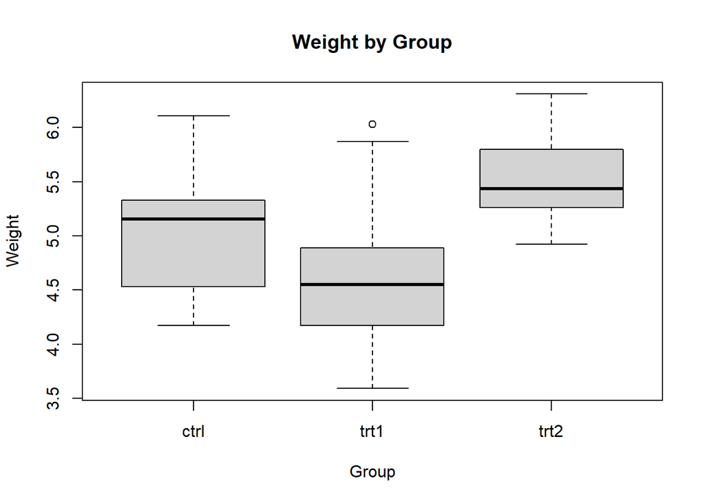

```r
# Enter your code here!
boxplot(weight ~ group, data = PlantGrowth,
        xlab = "Group", ylab = "Weight",
        main = "Weight by Group")
```

Result:

2. Using the **mtcars** data set, plot the histogram for the column **mpg** with 10 breaks. Give labels to the title, x-axis, and y-axis on the graph. Report the most observed mpg class from the data set.

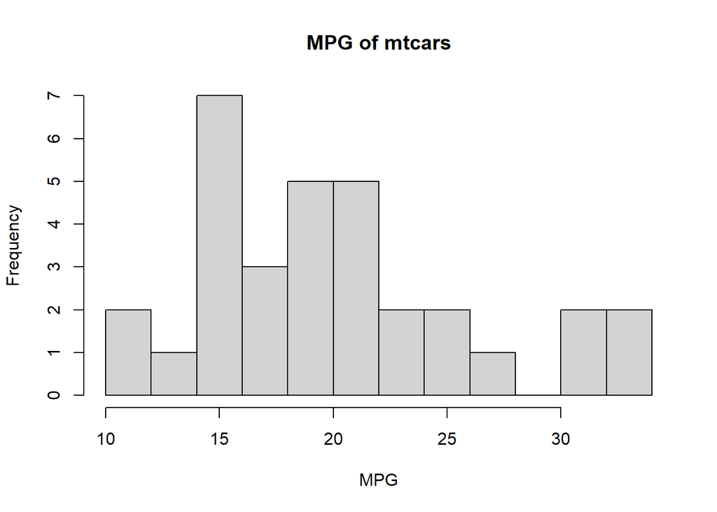

```r
hist(mpg, breaks = 10, main = "MPG of mtcars", xlab = "MPG", ylab = "Frequency")
```

```r
print("Most of the cars in this data set are in the class of 15 mile per gallon.")
```

```
## [1] "Most of the cars in this data set are in the class of 15 mile per gallon."
```

3. Using the **USArrests** data set, create a pairs plot to display the correlations between the variables in the data set. Plot the scatter plot with **Murder** and **Assault**. Give labels to the title, x-axis, and y-axis on the graph. Write a paragraph to summarize your results from both plots.

```r
# Load the data set
data("USArrests")

# Head of the data set
head(USArrests)
```

|  | Murder | Assault | UrbanPop | Rape |
| --- | --- | --- | --- | --- |
| Alabama | 13.2 | 236 | 58 | 21.2 |
| Alaska | 10.0 | 263 | 48 | 44.5 |
| Arizona | 8.1 | 294 | 80 | 31.0 |
| Arkansas | 8.8 | 190 | 50 | 19.5 |
| California | 9.0 | 276 | 91 | 40.6 |
| Colorado | 7.9 | 204 | 78 | 38.7 |

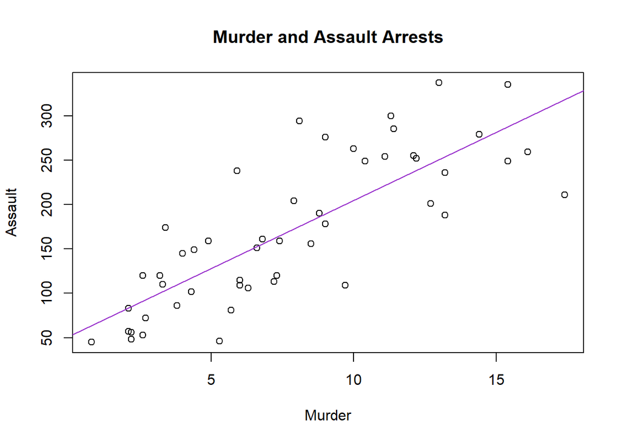

```r
# Enter your code here!
murder <- USArrests$Murder
assault <- USArrests$Assault
plot(murder, assault, xlab = "Murder", ylab = "Assault", main = "Murder and Assault Arrests")
abline(lm(assault ~ murder), col = "darkorchid")
```

Result:

=> Report a paragraph to summarize your findings from the plot!

As murder arrests increases, so does assault arrests. We see that there is a positive correlation between these two variables. There are also plenty of points that stray from the line. Some of them show that assault is high when murder is low and vice versa, but considering this dataset has 1973 statistics on murder, assault, and rape arrests per 100,000 population in each of the 50 states, there will be variability across each state.

### Question 3

Download the housing data set from www.jaredlander.com and find out what explains the housing prices in New York City.

Note: Check your working directory to make sure that you can download the data into the data folder.

1. Create your own descriptive statistics and aggregation tables to summarize the data set and find any meaningful results between different variables in the data set.

```r
# Head of the cleaned data set
head(housingData)
```

|  | Neighborhood | Market.Value.per.SqFt | Boro | Year.Built |
| --- | --- | --- | --- | --- |
| 1 | FINANCIAL | 200.00 | Manhattan | 1920 |
| 2 | FINANCIAL | 242.76 | Manhattan | 1985 |
| 4 | FINANCIAL | 271.23 | Manhattan | 1930 |
| 5 | TRIBECA | 247.48 | Manhattan | 1985 |
| 6 | TRIBECA | 191.37 | Manhattan | 1986 |
| 7 | TRIBECA | 211.53 | Manhattan | 1985 |

```r
# Enter your code here!

neighbor <- as.factor(housingData$Neighborhood)
market <- housingData$Market.Value.per.SqFt
boro <- as.factor(housingData$Boro)
year <- housingData$Year.Built
# summary
summary(housingData)
```

```
##  Neighborhood       Market.Value.per.SqFt     Boro             Year.Built
##  Length:2530        Min.   : 10.66        Length:2530        Min.   :1825
##  Class :character   1st Qu.: 75.10        Class :character   1st Qu.:1926
##  Mode  :character   Median :114.89        Mode  :character   Median :1986
##                     Mean   :133.17                           Mean   :1967
##                     3rd Qu.:189.91                           3rd Qu.:2005
##                     Max.   :399.38                           Max.   :2010
```

```r
summary(neighbor)
```

```
##            FLUSHING-NORTH   UPPER EAST SIDE (59-79)            HARLEM-CENTRAL
##                       133                       123                        94
##                   CHELSEA   UPPER WEST SIDE (59-79)   UPPER EAST SIDE (79-96)
##                        88                        87                        78
##                   TRIBECA   UPPER WEST SIDE (79-96) GREENWICH VILLAGE-CENTRAL
##                        74                        66                        60
##      WILLIAMSBURG-CENTRAL        BEDFORD STUYVESANT    GREENWICH VILLAGE-WEST
##                        60                        58                        57
##              MIDTOWN EAST                  ELMHURST                      SOHO
##                        56                        55                        55
##              MIDTOWN WEST                  FLATIRON           LOWER EAST SIDE
##                        47                        45                        42
##               MURRAY HILL         WILLIAMSBURG-EAST                 FINANCIAL
##                        39                        38                        36
##               HARLEM-EAST              BOROUGH PARK  UPPER WEST SIDE (96-116)
##                        36                        35                        34
##        WILLIAMSBURG-SOUTH                   CLINTON                PARK SLOPE
##                        34                        31                        31
##                   ASTORIA                 REGO PARK            SHEEPSHEAD BAY
##                        30                        27                        27
##              EAST VILLAGE        WILLIAMSBURG-NORTH             ALPHABET CITY
##                        26                        26                        24
##          LONG ISLAND CITY              CIVIC CENTER          MANHATTAN VALLEY
##                        24                        23                        23
##               SUNSET PARK            BRIGHTON BEACH                 CHINATOWN
##                        23                        21                        21
##           JACKSON HEIGHTS                 GRAVESEND                GREENPOINT
##                        21                        19                        19
##                   MADISON                    CORONA              FOREST HILLS
##                        19                        17                        17
##                  GRAMERCY                 RIVERDALE       MORRISANIA/LONGWOOD
##                        17                        17                        16
##               BOERUM HILL                   FASHION             CROWN HEIGHTS
##                        15                        15                        14
##     DOWNTOWN-FULTON FERRY              CLINTON HILL                  KIPS BAY
##                        14                        13                        13
##              LITTLE ITALY               MIDTOWN CBD              HARLEM-UPPER
##                        13                        13                        12
##                   MIDWOOD                 SUNNYSIDE               FORT GREENE
##                        11                        11                        10
```

[output cut: 13 more lines]

```
##                         6                         6                         6
##               COBBLE HILL                   HAMMELS              HOWARD BEACH
##                         5                         5                         5
##                   JAMAICA   KINGSBRIDGE/JEROME PARK          PROSPECT HEIGHTS
##                         5                         5                         5
##             ROCKAWAY PARK  UPPER EAST SIDE (96-110)  WASHINGTON HEIGHTS LOWER
##                         5                         5                         5
##           WINDSOR TERRACE                 BRIARWOOD                  CANARSIE
##                         5                         4                         4
##              CONEY ISLAND              FAR ROCKAWAY                   MASPETH
##                         4                         4                         4
##                 WOODHAVEN                 BRONXDALE             COLLEGE POINT
##                         4                         3                         3
##                   (Other)
##                        79
```

```r
summary(boro)
```

```
##         Bronx      Brooklyn     Manhattan        Queens Staten Island
##            69           626          1379           432            24
```

```r
# table
aggregate(market, by = list(boro), FUN = function(x) c(mean = mean(x), sd = sd(x)))
```

[output not shown]

```r
table(neighbor)
```

```
## neighbor
##             ALPHABET CITY      ARROCHAR-SHORE ACRES                   ASTORIA
##                        24                         1                        30
##                BATH BEACH                 BAY RIDGE                   BAYSIDE
##                         6                         8                         9
##      BEDFORD PARK/NORWOOD        BEDFORD STUYVESANT                   BELMONT
##                         2                        58                         1
##               BENSONHURST              BERGEN BEACH               BOERUM HILL
##                         7                         1                        15
##              BOROUGH PARK                 BRIARWOOD            BRIGHTON BEACH
##                        35                         4                        21
##             BRONX-UNKNOWN                 BRONXDALE          BROOKLYN HEIGHTS
##                         2                         3                         9
##             BUSH TERMINAL                  BUSHWICK                  CANARSIE
##                         1                         2                         4
##           CARROLL GARDENS                   CHELSEA                 CHINATOWN
##                         9                        88                        21
##               CITY ISLAND              CIVIC CENTER                   CLINTON
##                         1                        23                        31
##              CLINTON HILL               COBBLE HILL          COBBLE HILL-WEST
##                        13                         5                         8
##             COLLEGE POINT              CONEY ISLAND                    CORONA
##                         3                         4                        17
##             CROWN HEIGHTS     DOWNTOWN-FULTON FERRY      DOWNTOWN-FULTON MALL
##                        14                        14                         2
##        DOWNTOWN-METROTECH             DYKER HEIGHTS             EAST NEW YORK
##                         3                         1                         6
##              EAST TREMONT              EAST VILLAGE                  ELMHURST
##                         3                        26                        55
##              FAR ROCKAWAY                   FASHION                 FINANCIAL
##                         4                        15                        36
##          FLATBUSH-CENTRAL  FLATBUSH-LEFFERTS GARDEN            FLATBUSH-NORTH
##                         6                         1                         8
##                  FLATIRON            FLUSHING-NORTH            FLUSHING-SOUTH
##                        45                       133                         8
##      FLUSHING MEADOW PARK              FOREST HILLS               FORT GREENE
##                         1                        17                        10
##                  GLENDALE                   GOWANUS                  GRAMERCY
##                         3                         3                        17
##                GRANT CITY                 GRAVESEND               GREAT KILLS
```

[output cut: 46 more lines]

```
##                         3                         1                        74
##   UPPER EAST SIDE (59-79)   UPPER EAST SIDE (79-96)  UPPER EAST SIDE (96-110)
##                       123                        78                         5
##   UPPER WEST SIDE (59-79)   UPPER WEST SIDE (79-96)  UPPER WEST SIDE (96-116)
##                        87                        66                        34
##  WASHINGTON HEIGHTS LOWER  WASHINGTON HEIGHTS UPPER         WEST NEW BRIGHTON
##                         5                         6                         1
##                WHITESTONE            WILLIAMSBRIDGE      WILLIAMSBURG-CENTRAL
##                         2                         2                        60
##         WILLIAMSBURG-EAST        WILLIAMSBURG-NORTH        WILLIAMSBURG-SOUTH
##                        38                        26                        34
##           WINDSOR TERRACE                 WOODHAVEN                  WOODSIDE
##                         5                         4                         8
##           WYCKOFF HEIGHTS
##                         3
```

```r
table(neighbor, boro)
```

```
##                            boro
## neighbor                    Bronx Brooklyn Manhattan Queens Staten Island
##   ALPHABET CITY                 0        0        24      0             0
##   ARROCHAR-SHORE ACRES          0        0         0      0             1
##   ASTORIA                       0        0         0     30             0
##   BATH BEACH                    0        6         0      0             0
##   BAY RIDGE                     0        8         0      0             0
##   BAYSIDE                       0        0         0      9             0
##   BEDFORD PARK/NORWOOD          2        0         0      0             0
##   BEDFORD STUYVESANT            0       58         0      0             0
##   BELMONT                       1        0         0      0             0
##   BENSONHURST                   0        7         0      0             0
##   BERGEN BEACH                  0        1         0      0             0
##   BOERUM HILL                   0       15         0      0             0
##   BOROUGH PARK                  0       35         0      0             0
##   BRIARWOOD                     0        0         0      4             0
##   BRIGHTON BEACH                0       21         0      0             0
##   BRONX-UNKNOWN                 2        0         0      0             0
##   BRONXDALE                     3        0         0      0             0
##   BROOKLYN HEIGHTS              0        9         0      0             0
##   BUSH TERMINAL                 0        1         0      0             0
##   BUSHWICK                      0        2         0      0             0
##   CANARSIE                      0        4         0      0             0
##   CARROLL GARDENS               0        9         0      0             0
##   CHELSEA                       0        0        88      0             0
##   CHINATOWN                     0        0        21      0             0
##   CITY ISLAND                   1        0         0      0             0
##   CIVIC CENTER                  0        0        23      0             0
##   CLINTON                       0        0        31      0             0
##   CLINTON HILL                  0       13         0      0             0
##   COBBLE HILL                   0        5         0      0             0
##   COBBLE HILL-WEST              0        8         0      0             0
##   COLLEGE POINT                 0        0         0      3             0
##   CONEY ISLAND                  0        4         0      0             0
##   CORONA                        0        0         0     17             0
##   CROWN HEIGHTS                 0       14         0      0             0
##   DOWNTOWN-FULTON FERRY         0       14         0      0             0
##   DOWNTOWN-FULTON MALL          0        2         0      0             0
##   DOWNTOWN-METROTECH            0        3         0      0             0
##   DYKER HEIGHTS                 0        1         0      0             0
```

[output cut: 95 more lines]

```
##   UPPER WEST SIDE (79-96)       0        0        66      0             0
##   UPPER WEST SIDE (96-116)      0        0        34      0             0
##   WASHINGTON HEIGHTS LOWER      0        0         5      0             0
##   WASHINGTON HEIGHTS UPPER      0        0         6      0             0
##   WEST NEW BRIGHTON             0        0         0      0             1
##   WHITESTONE                    0        0         0      2             0
##   WILLIAMSBRIDGE                2        0         0      0             0
##   WILLIAMSBURG-CENTRAL          0       60         0      0             0
##   WILLIAMSBURG-EAST             0       38         0      0             0
##   WILLIAMSBURG-NORTH            0       26         0      0             0
##   WILLIAMSBURG-SOUTH            0       34         0      0             0
##   WINDSOR TERRACE               0        5         0      0             0
##   WOODHAVEN                     0        0         0      4             0
##   WOODSIDE                      0        0         0      8             0
##   WYCKOFF HEIGHTS               0        3         0      0             0
```

```r
table(neighbor, cut(year, breaks = seq(min(year), max(year), by = 10)))
```

```
##
## neighbor                    (1825,1835] (1835,1845] (1845,1855] (1855,1865]
##   ALPHABET CITY                       0           0           0           0
##   ARROCHAR-SHORE ACRES                0           0           0           0
##   ASTORIA                             0           0           0           0
##   BATH BEACH                          0           0           0           0
##   BAY RIDGE                           0           0           0           0
##   BAYSIDE                             0           0           0           0
##   BEDFORD PARK/NORWOOD                0           0           0           0
##   BEDFORD STUYVESANT                  0           0           0           0
##   BELMONT                             0           0           0           0
##   BENSONHURST                         0           0           0           0
##   BERGEN BEACH                        0           0           0           0
##   BOERUM HILL                         0           0           0           0
##   BOROUGH PARK                        0           0           0           0
##   BRIARWOOD                           0           0           0           0
##   BRIGHTON BEACH                      0           0           0           0
##   BRONX-UNKNOWN                       0           0           0           0
##   BRONXDALE                           0           0           0           0
##   BROOKLYN HEIGHTS                    0           0           0           0
##   BUSH TERMINAL                       0           0           0           0
##   BUSHWICK                            0           0           0           0
##   CANARSIE                            0           0           0           0
##   CARROLL GARDENS                     0           0           0           0
##   CHELSEA                             0           0           0           0
##   CHINATOWN                           0           0           0           0
##   CITY ISLAND                         0           0           0           0
##   CIVIC CENTER                        0           0           0           2
##   CLINTON                             0           0           0           0
##   CLINTON HILL                        0           0           0           0
##   COBBLE HILL                         0           0           0           0
##   COBBLE HILL-WEST                    0           0           0           0
##   COLLEGE POINT                       0           0           0           0
##   CONEY ISLAND                        0           0           0           0
##   CORONA                              0           0           0           0
##   CROWN HEIGHTS                       0           0           0           0
##   DOWNTOWN-FULTON FERRY               0           0           0           0
##   DOWNTOWN-FULTON MALL                0           0           0           0
##   DOWNTOWN-METROTECH                  0           0           0           0
##   DYKER HEIGHTS                       0           0           0           0
```

[output cut: 695 more lines]

```
##   UPPER WEST SIDE (79-96)            13           2
##   UPPER WEST SIDE (96-116)            3           3
##   WASHINGTON HEIGHTS LOWER            0           0
##   WASHINGTON HEIGHTS UPPER            0           2
##   WEST NEW BRIGHTON                   1           0
##   WHITESTONE                          0           0
##   WILLIAMSBRIDGE                      0           1
##   WILLIAMSBURG-CENTRAL                1          45
##   WILLIAMSBURG-EAST                   0          22
##   WILLIAMSBURG-NORTH                  0           2
##   WILLIAMSBURG-SOUTH                  1          21
##   WINDSOR TERRACE                     1           1
##   WOODHAVEN                           0           0
##   WOODSIDE                            3           3
##   WYCKOFF HEIGHTS                     0           0
```

2. Create multiple plots to demonstrates the correlations between different variables. Remember to label all axes and give title to each graph.

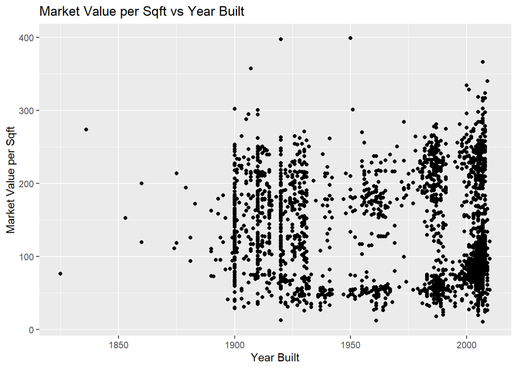

```r
# Enter your code here!

library(ggplot2)
library(dplyr)
# variable
avgMarket <- tapply(market, boro, mean)
# plot
ggplot(data = housingData, aes(x = year, y = market)) +
  geom_point() +
  labs(title = "Market Value per Sqft vs Year Built",
       x = "Year Built",
       y = "Market Value per Sqft")
```

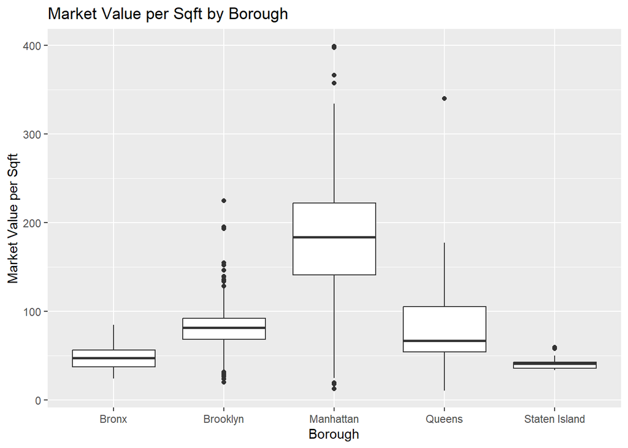

```r
ggplot(data = housingData, aes(x = boro, y = market)) +
  geom_boxplot() +
  labs(title = "Market Value per Sqft by Borough",
       x = "Borough",
       y = "Market Value per Sqft")
```

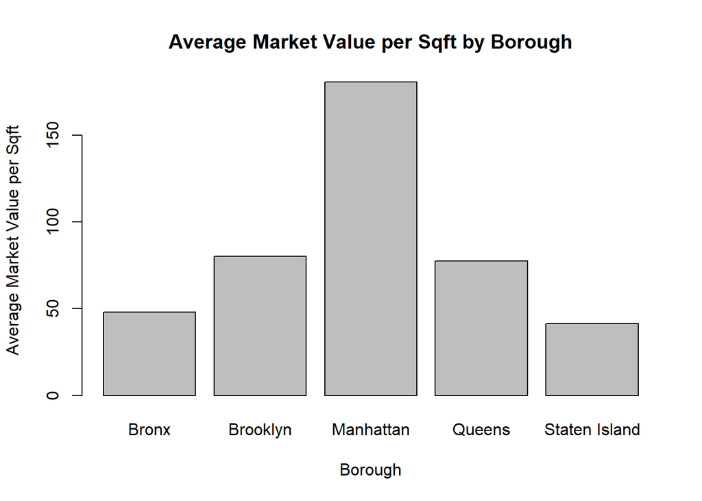

```r
barplot(avgMarket,
        main = "Average Market Value per Sqft by Borough",
        xlab = "Borough",
        ylab = "Average Market Value per Sqft")
```

3. Write a summary about your findings from this exercise.